# LESSON 4: NUMPY INTRODUCTION

[figure not shown]

## 1. Overall introduction

"The fundamental package for scientific computing with Python."  
NumPy official document is available [here](https://numpy.org/doc/stable/).  
NumPy official open-source is [here](https://github.com/numpy/numpy).  
Compare with Python `list`, NumPy is FAST and MEMORY EFFIENCY!!! (computing on vector and single data type)

### 1.1. Vectorization

```python
# Python list

list_a = [1, 2, 3] * 1_000_000
list_b = [10, 11, 12] * 1_000_000
list_results = []

for index in range(len(list_a)):
    list_results.append(list_a[index] + list_b[index])

# print(list_results)
```

```python
# Numpy

np_a = np.array([1, 2, 3] * 1_000_000)
np_b = np.array([10, 11, 12] * 1_000_000)

np_results = np_a + np_b
# print(np_results)
```

### 1.2. Broadcasting

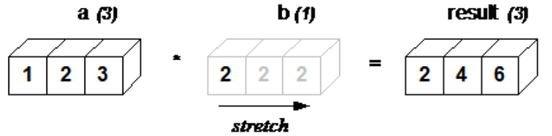

In the simplest example of broadcasting, the scalar `b` is stretched to become an array of same shape as `a` so the shapes are compatible for element-by-element multiplication.

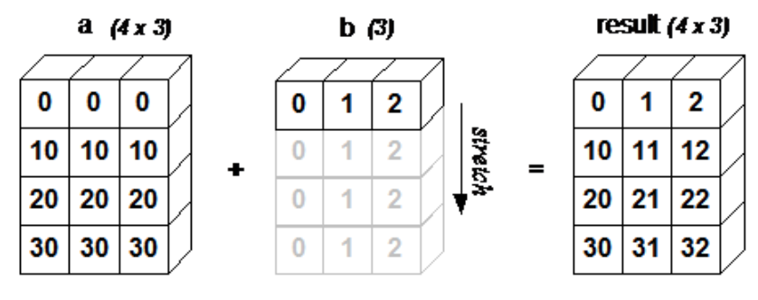

A two dimensional array added by a one dimensional array results in broadcasting if number of 1-d array elements matches the number of 2-d array columns.

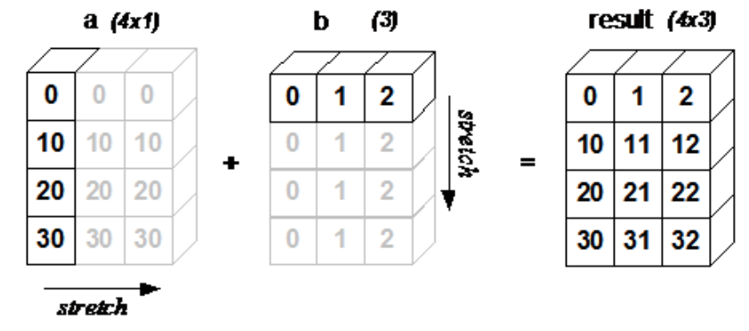

In some cases, broadcasting stretches both arrays to form an output array larger than either of the initial arrays.

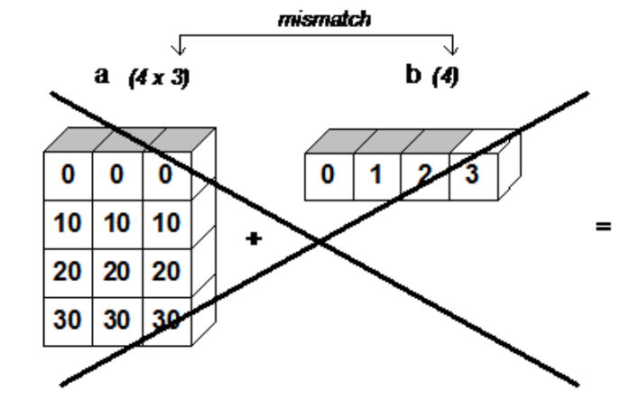

When the trailing dimensions of the arrays are unequal, broadcasting fails because it is impossible to align the values in the rows of the 1st array with the elements of the 2nd arrays for element-by-element addition.

## 2. Install and import numpy

```python
!pip install numpy
```

```python
import numpy as np
```

## 3. Get started with numpy ndarray

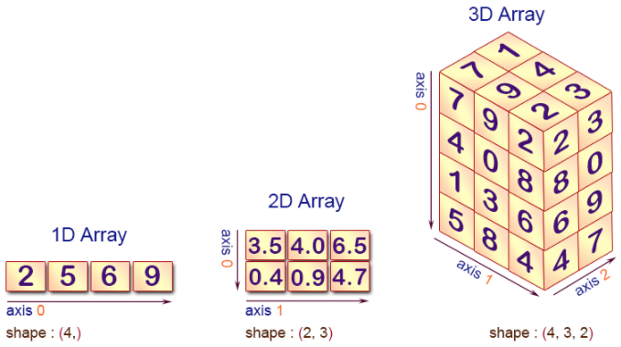

### Create ndarray

| Data type | Description |
| --- | --- |
| `bool_` | Boolean (True or False) stored as a byte |
| `int_` | Default integer type (same as C `long`; normally either `int64` or `int32`) |
| `intc` | Identical to C `int` (normally `int32` or `int64`) |
| `intp` | Integer used for indexing (same as C `ssize_t`; normally either `int32` or `int64`) |
| `int8` | Byte (-128 to 127) |
| `int16` | Integer (-32768 to 32767) |
| `int32` | Integer (-2147483648 to 2147483647) |
| `int64` | Integer (-9223372036854775808 to 9223372036854775807) |
| `uint8` | Unsigned integer (0 to 255) |
| `uint16` | Unsigned integer (0 to 65535) |
| `uint32` | Unsigned integer (0 to 4294967295) |
| `uint64` | Unsigned integer (0 to 18446744073709551615) |
| `float_` | Shorthand for `float64`. |
| `float16` | Half precision float: sign bit, 5 bits exponent, 10 bits mantissa |
| `float32` | Single precision float: sign bit, 8 bits exponent, 23 bits mantissa |
| `float64` | Double precision float: sign bit, 11 bits exponent, 52 bits mantissa |
| `complex_` | Shorthand for `complex128`. |
| `complex64` | Complex number, represented by two 32-bit floats |
| `complex128` | Complex number, represented by two 64-bit floats |

```python
# Create a length-10 integer array filled with zeros
np.zeros(10, dtype=int)
```

```python
# Create a 3x5 floating-point array filled with ones
np.ones((3, 5), dtype=float)
```

```python
# Create a 3x5 array filled with 3.14
np.full((3, 5), np.pi)
```

```python
# Create an array filled with a linear sequence
# Starting at 0, ending at 20, stepping by 2
# (this is similar to the built-in range() function)
np.arange(0, 20, 2)
```

```python
# Create an array of five values evenly spaced between 0 and 1
np.linspace(0, 1, 5)
```

```python
# Create a 3x3 array of uniformly distributed
# random values between 0 and 1
np.random.random((3, 3))
```

```python
# Create a 3x3 array of normally distributed random values
# with mean 0 and standard deviation 1
np.random.normal(0, 1, (3, 3))
```

### Show ndarray's attributes

```python
x = np.random.randint(10, size=(3, 4, 5))
x
```

```python
x.ndim # Number of dimensions
```

```python
x.shape # Detail size each dimension
```

```python
x.size # Total elements in array
```

```python
x.dtype # Data type used in array
```

```python
x.itemsize # Size (in bytes) of each element
```

```python
x.nbytes # Total size of all elements in array
```

### Access elements in ndarray by index

```python
x
```

```python
x[1]
```

```python
x[1, 1]
```

```python
x[1, 1, 1]
```

```python
x[1, 1, 1] = 999
x
```

```python
x[-1]
```

### Slice ndarray by index and `:`

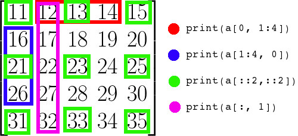

```python
x
```

```python
x[1:]
```

```python
x[1:, 1:]
```

```python
x[1:, 1:, 1:]
```

```python
x[1:, 1:, 1:] = np.full((2, 3, 4), 888)
x
```

### Slice ndarray with step

```python
y = x[0, 0]
y
```

```python
y[::2] # start = 0 (first index), stop = 5 (last index + 1), step = 2
```

```python
y[::-2] # step is negative => start and stop are swapped
```

## 4. Computation on ndarrays

| Operator | Equivalent ufunc | Description |
| --- | --- | --- |
| `+` | `np.add` | Addition (e.g., `1 + 1 = 2`) |
| `-` | `np.subtract` | Subtraction (e.g., `3 - 2 = 1`) |
| `-` | `np.negative` | Unary negation (e.g., `-2`) |
| `*` | `np.multiply` | Multiplication (e.g., `2 * 3 = 6`) |
| `/` | `np.divide` | Division (e.g., `3 / 2 = 1.5`) |
| `//` | `np.floor_divide` | Floor division (e.g., `3 // 2 = 1`) |
| `**` | `np.power` | Exponentiation (e.g., `2 ** 3 = 8`) |
| `%` | `np.mod` | Modulus/remainder (e.g., `9 % 4 = 1`) |

```python
x = np.arange(5)
x
```

```python
y = np.arange(10, 20, 2)
y
```

```python
x + 10
```

```python
np.add(x, 10)
```

```python
x + y
```

```python
np.add(x, y)
```

```python
x - 2
```

```python
np.subtract(x, 2)
```

```python
x - y
```

```python
np.subtract(x, y)
```

```python
x * 3
```

```python
np.multiply(x, 3)
```

```python
x * y
```

```python
np.multiply(x, y)
```

```python
x / 2
```

```python
np.divide(x, 2)
```

```python
x / y
```

```python
np.divide(x, y)
```

```python
x // 2
```

```python
np.floor_divide(x, 2)
```

```python
x // y
```

```python
np.floor_divide(x, y)
```

```python
x % 2
```

```python
np.mod(x, 2)
```

```python
x % y
```

```python
np.mod(x, y)
```

```python
x ** 2
```

```python
np.power(x, 2)
```

```python
x ** y
```

```python
np.power(x, y)
```

```python
pi_array = np.linspace(-1 * np.pi, np.pi, 5)
pi_array
```

```python
np.sin(pi_array)
```

```python
np.cos(pi_array)
```

```python
np.tan(pi_array)
```

```python
np.arcsin(np.sin(pi_array))
```

```python
np.arccos(np.cos(pi_array))
```

```python
np.arctan(np.tan(pi_array))
```

```python
np.exp(x)
```

```python
np.exp2(x)
```

```python
np.power(3, x)
```

```python
np.log(x + 1)
```

```python
np.log2(x + 1)
```

```python
np.log10(x + 1)
```

## 5. Simple functions with ndarray

### Reshape ndarray

```python
z = np.arange(12)
z
```

```python
z.shape
```

```python
z_reshape = z.reshape((12, 1))
z_reshape
```

```python
z_reshape.shape
```

```python
z_reshape = z.reshape((1, 12))
z_reshape
```

```python
z_reshape.shape
```

```python
z.reshape((4, 3))
```

```python
z.reshape((2, 2, 3))
```

### Change number of dims, position of dims

#### Change number of dims by using `np.expand_dims()` and `np.squeeze()`

```python
z
```

```python
z.shape
```

```python
z_1 = np.expand_dims(z, axis=1)
z_1
```

```python
z_1.shape
```

```python
z_0 = np.expand_dims(z, axis=0)
z_0
```

```python
z_0.shape
```

```python
np.squeeze(z_0, axis=0)
```

```python
np.squeeze(z_1, axis=1)
```

#### Change position of dims by using `np.transpose()`

```python
z_1
```

```python
z_1.shape
```

```python
z_1_trans = np.transpose(z_1, [1, 0])
z_1_trans
```

```python
z_1_trans.shape
```

### Concatenate ndarray

#### Using `np.concatenate()`

```python
x = np.array([1, 2, 3])
y = np.array([4.4, 5.5, 6.6])
z = np.array([7.77, 8.88, 9.99])
```

```python
x
```

```python
y
```

```python
z
```

```python
np.concatenate([x, y])
```

```python
np.concatenate([x, y, z])
```

```python
xx = np.array([[1, 2, 3], [3, 2, 1]])
yy = np.array([[4.4, 5.5, 6.6], [6.6, 5.5, 4.4]])
```

```python
xx.shape
```

```python
yy.shape
```

```python
np.concatenate([xx, yy], axis=0)
```

```python
np.concatenate([xx, yy], axis=1)
```

#### Using `np.hstack()`(horizontal stack), `np.vstack()`(vertical stack) and `np.dstack()`(depth stack)

```python
np.hstack([xx, yy])
```

```python
np.vstack([xx, yy])
```

```python
np.dstack([xx, yy])
```

## 6. Data aggregation on ndarray

| Function Name | NaN-safe Version | Description |
| --- | --- | --- |
| `np.sum` | `np.nansum` | Compute sum of elements |
| `np.prod` | `np.nanprod` | Compute product of elements |
| `np.mean` | `np.nanmean` | Compute mean of elements |
| `np.std` | `np.nanstd` | Compute standard deviation |
| `np.var` | `np.nanvar` | Compute variance |
| `np.min` | `np.nanmin` | Find minimum value |
| `np.max` | `np.nanmax` | Find maximum value |
| `np.argmin` | `np.nanargmin` | Find index of minimum value |
| `np.argmax` | `np.nanargmax` | Find index of maximum value |
| `np.median` | `np.nanmedian` | Compute median of elements |
| `np.percentile` | `np.nanpercentile` | Compute rank-based statistics of elements |
| `np.any` | N/A | Evaluate whether any elements are true |
| `np.all` | N/A | Evaluate whether all elements are true |

### Compare between built-in python `sum()` and `np.sum()`

```python
big_array = np.random.rand(1_000_000)
big_array.shape
```

```python
sum(big_array)
```

```python
np.sum(big_array)
```

```python
%timeit sum(big_array)
```

```python
%timeit np.sum(big_array)
```

```python
x = np.random.randint(0, 10, (2, 5))
x
```

```python
sum(x)
```

```python
np.sum(x)
```

```python
np.sum(x, axis=1)
```

```python
np.sum(x, axis=0)
```

### Compare between built-in python `min(), max()` and `np.min(), np.max()`

```python
min(big_array), max(big_array)
```

```python
np.min(big_array), np.max(big_array)
```

```python
%timeit min(big_array)
%timeit np.min(big_array)
```

```python
%timeit max(big_array)
%timeit np.max(big_array)
```

```python
x
```

```python
x.shape
```

```python
min(x), max(x)
```

```python
np.min(x), np.max(x)
```

```python
np.min(x, axis=0), np.max(x, axis=0)
```

```python
np.min(x, axis=1), np.max(x, axis=1)
```

```python
x
```

```python
np.any(x > 3)
```

```python
np.all(x > 3)
```

## 7. Ndarray with logical functions

### Simple logical functions

```python
x
```

```python
x > 2
```

```python
x >= 2
```

```python
x < 2
```

```python
x <= 2
```

```python
x == 2
```

```python
x != 2
```

```python
np.all(x > 2)
```

```python
np.all(x >= 0)
```

```python
np.any(x > 2)
```

```python
np.any(x < 0)
```

### Use logical functions as mask

```python
x
```

```python
x > 3
```

```python
x[x > 3]
```

## 8. Homework

### 8.1. Exercise 1:

Write a NumPy program to convert a list of numeric value into a one-dimensional NumPy array.

### 8.2. Exercise 2:

Write a NumPy program to create a 3x3 matrix with values ranging from 2 to 10.

### 8.3. Exercise 3:

Write a NumPy program to reverse an array (first element becomes last).

### 8.4. Exercise 4:

Write a NumPy program to convert an array to a float type.

### 8.5. Exercise 5:

Write a NumPy program to create a 2d array with 1 on the border and 0 inside.

### 8.6. Exercise 6:

Write a NumPy program to create a 8x8 matrix and fill it with a checkerboard pattern.

### 8.7. Exercise 7:

Write a NumPy program to convert the values of Centigrade degrees into Fahrenheit degrees. Centigrade values are stored into a NumPy array.

### 8.8. Exercise 8:

Write a NumPy program to get the indices of the sorted elements of a given array.